sampling distribution $y|\theta \sim BINOM(2430, \theta)$

An ‘expert’ states a strong belief that $\theta \in (0.05, 0.15)$. We interpret this expert opinion as $P(\theta\in (0.05, 0.15)=0.95$, therefore $P(\theta<0.05)=0.025$ and $P(\theta>0.15)=0.025$ A possible prior for $\theta$ is a Beta distribution, where the values of shape parameters $\alpha$ and $\beta$ are chosen to reflect our uncertainty about $\theta$. The package `LearnBayes` contains the `beta.select()` function that returns the beta distribution shape parameters.

```r
library(LearnBayes)
quantile1 <- list(p = 0.025, x = 0.05)
quantile2 <- list(p = 0.975, x = 0.15)
shapes <- beta.select(quantile1 = quantile1,
                      quantile2 = quantile2)
s1 <- shapes[1] ; s2 <- shapes[2]
shapes
```

```
## [1]  12.08 116.55
```

Observing a plot of the beta pdf with these parameters shows that it does represent our uncertainty about $\theta$ expressed by expert opinion.

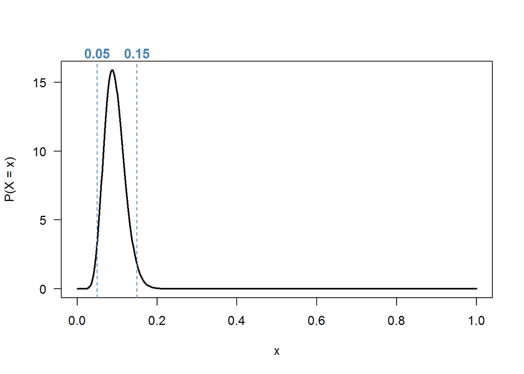

```r
curve(dbeta(x, s1, s2),
      n = 500,
      lwd = 2,
      lty = 1,
      las = 1,
      ylab = 'P(X = x)')
abline(v = c(0.05, 0.15),
       lty = 2,
       col = 'steelblue')
mtext(side = 3,
      text = c(0.05, 0.15),
      at = c(0.05, 0.15),
      col = 'steelblue',
      cex = 1.05,
      font = 2)
```

We want to find $P(\theta|y) = P(y|\theta)P(\theta)$ where

$$P(y|\theta)=\binom{2430}{219}\theta^{219}(1-\theta)^{2430-219}$$

and

$$P(\theta) = \frac{\Gamma(12.08+116.55)}{\Gamma(12.08)\Gamma(116.55)}\theta^{12.08-1}(1-\theta)^{116.55-1}$$

Taking the product we see that

$$\begin{aligned}
P(\theta|y) &= P(y|\theta)P(\theta)\\\\
&=C\left[\theta^{219}(1-\theta)^{2430-219}\times\theta^{12.08-1}(1-\theta)^{116.55-1}\right]\\\\
&=C\left[\theta^{219+12.08-1} (1-\theta)^{2430-219+116.55 -1}\right]\\\\
&=C\left[\theta^{231.08-1} (1-\theta)^{2327.55-1}\right]
\end{aligned}$$

where $C$ is a constant with value

$$C = \binom{2430}{219} \times \frac{\Gamma(12.08+116.55)}{\Gamma(12.08)\Gamma(116.55)}$$

This suggests that the posterior distribution of $\theta$ (i.e. the distribution after merging our observed data with our expert opinion) follow a $BETA(231.08,2327.55)$. Adding a plot of the posterior pdf to the above plot of the prior pdf reveals how the data has shifted our belief.

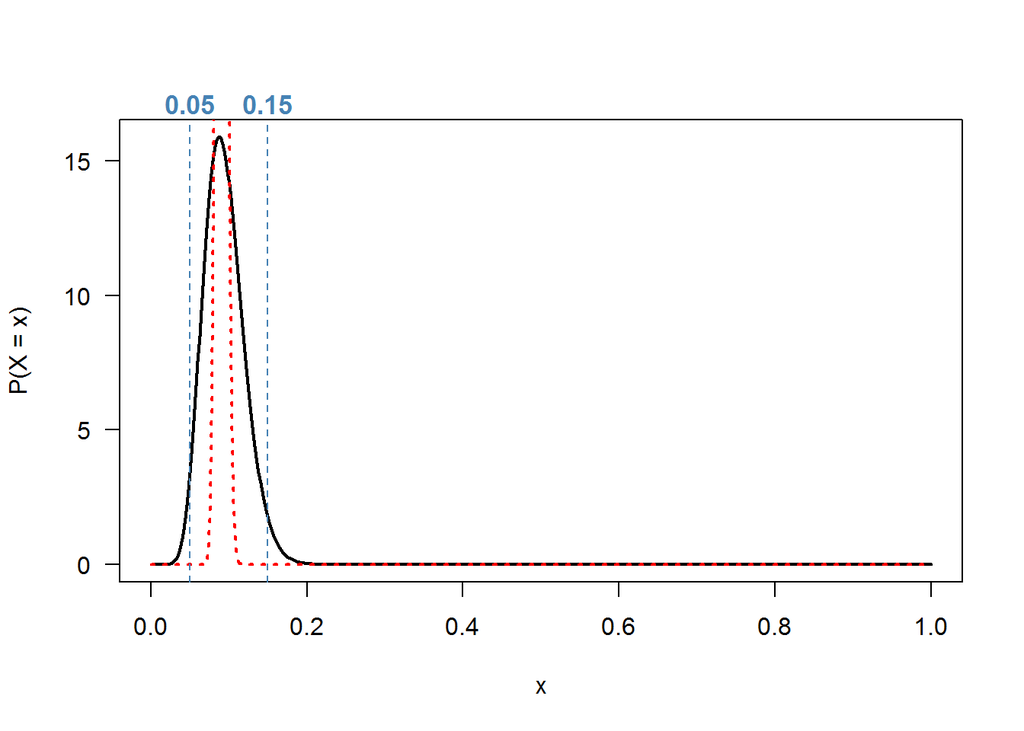

```r
curve(dbeta(x, s1, s2),
      n = 500,
      lwd = 2,
      lty = 1,
      las = 1,
      ylab = 'P(X = x)')
curve(dbeta(x, 219+s1,2430-219+s2),
      n = 500,
      lwd = 2,
      lty = 3,
      col = 2,
      add = T)
abline(v = c(0.05, 0.15),
       lty = 2,
       col = 'steelblue')
mtext(side = 3,
      text = c(0.05, 0.15),
      at = c(0.05, 0.15),
      col = 'steelblue',
      cex = 1.05,
      font = 2)
```